# Overview

This documentation is about version **0.1.15** (`Total Dynamism`), generated on 2017-2-23 .

# What is ALGT?

*ALGT* (*Automated Language Generation Tool* [^1]) is a tool to formally specify any programming language. This is done by first declaring a syntax, using BNF, and then declaring semantics by introducing logical deduction rules, such as evaluation or typing rules. Eventually, properties can be introduced which can be tested. Of course, these can be run.

The tool is kept as general as possible, so any language can be modelled.

# Tutorial: developing a simple programming language

We will develop a programming language which can work with booleans and integers. Apart from doing basic arithmetic, we can also use anonymous functions.

The expression `(\x : Int . x + 1)` is a *lambda expression*. This is an anonymous function, taking one argument - named x- of type `Int`. When applied (e.g. `(\x : Int . x + 1) 41`, the expression right of the `.` is returned, with the variable `x` substituted by the argument, becoming `41 + 1`.

## Setting up a language

A language is declared inside a `.language` file [^2]. Create `STFL.language`, and put a title in it:

You can put comments wherever you want after a `#`, e.g. to give some explanation about the language

## Declaring the syntax

For a full reference on syntax, see the reference manual on syntax.

### Simple booleans

A program is nothing more then a string of a specific form. To describe strings of an arbitrary structure, *BNF* [^3] can be used.

The syntax of our programming language is defined in the **Syntax**section of *STFL.language*:

What do we write here? Let's start with declaring the boolean values `True` and `False`. We express how these can be parsed by writing `bool ::= "True" | "False"`. This tells the tool that a syntactic form named `bool` exists and it is either `True` of `False`. Note the double quotes, these are important to indicate that we want this string literally. The `|` epxresses that it can choose between those forms.

Lets try running this! Create `examples.stfl`, which contains:

We can parse these by running (in your terminal) `./ALGT STFL.language examples.stfl bool -l`. The first argument is the language file, the second the examples, the `bool` tells ALGT what syntactic rule to parse. The `-l` flag expresses that each line should be treated individually.

### If-statements

Now, let's add expressions of the form `If True Then False Else True`. We define a new syntactic form: `expr ::= "If" bool "Then" bool "Else" bool`.[^4] This tell *ALGT* that an expression starts with a literal `If`, is followed by a `bool` (so either `True` or `False`), is followed by a literal `Then`, ... The tool uses the double quotes `"` to distinguish between a literal string and another syntactic form.

*STFL.language* now looks like:

This captures already some example expressions. Let's add `If True Then False Else True` to *examples.stfl*:

Let's run our tool, this time with `./ALGT STFL.language examples.stfl` **expr** `-l`

Oops! Seems like our parser now always wants to see a `If` in the beginning, and can't handle `True` anymore. Perhaps we should tell that a `bool` is a valid expression to:

What with a nested `If`?

`If If True Then False Else True Then True Else False` clearly can't be parsed, as the condition should be a `bool`, according to our current syntax.

Well, we can just write `expr` instead of `bool` in our syntax:

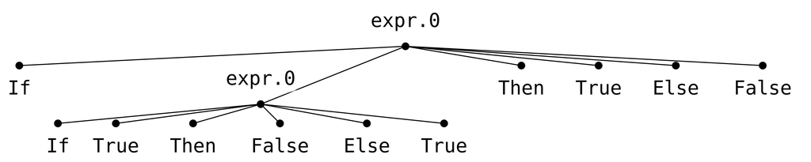

ParseTree of a nested condition[^6]

### Adding numbers, subtyping and forbidden left recursion

Time to spice things up with numbers. To make things easier, integers are built in as `Number`. It's good practice to introduce a new syntactic rule for them:

As an `int` is a valid expression, we add it to the `expr` form:

Note that every `int` now also is an `expr`, just as every `bool` is an `expr`. This typing relationship can be visualized with `ALGT STFL.language -lsvg Subtyping.svg`[^7] :

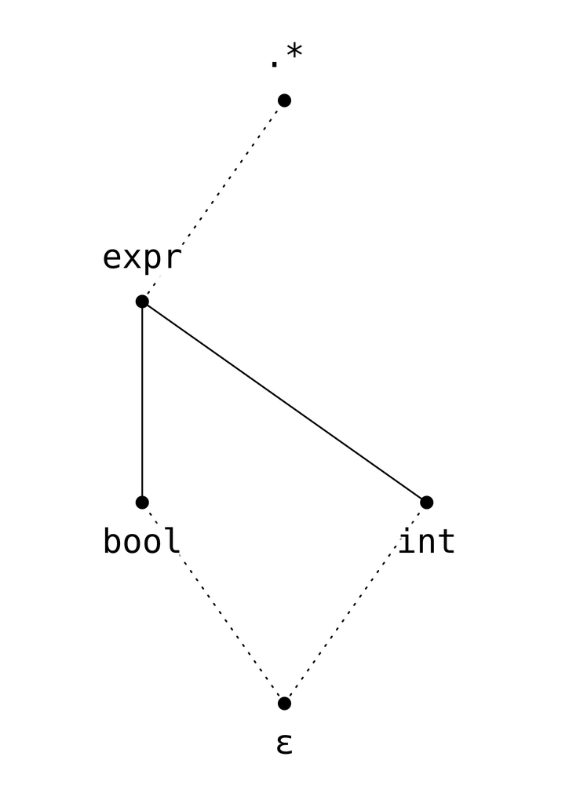

Subtyping relation of STFL.language

Now that numbers have been added, let's run this with a number as example:

So far, so good! Time to add addition:

We add some example:

The solution to this problem is splitting `expr` in two parts: a `term` with simple elements in front, and `expr` with advanced forms:

When we try again, we get:

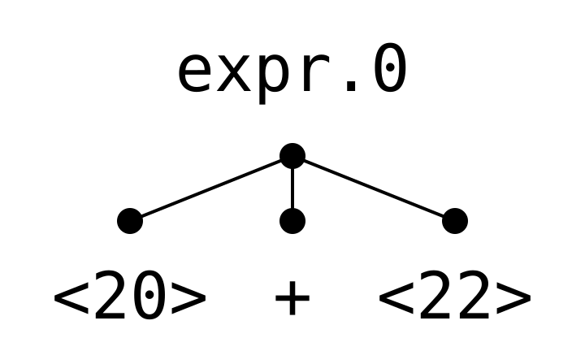

Parsetree of `20+22`

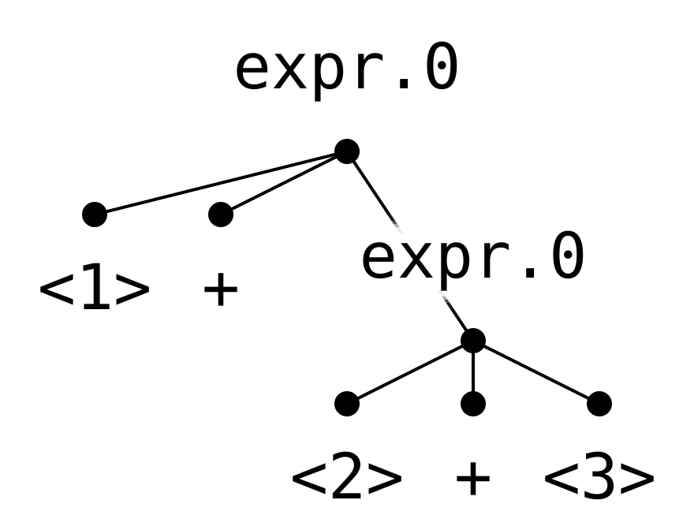

Parsetree of `1 + 2 + 3`

### Lambda expressions

The lambda expression is the last syntactic form we'd like to add. Recall that these look like `(\x : Int . x + 1)`.

#### Variables

The first thing we should deal with, are variables. A builtin is provided for those, namely `Identifiers`, matching all words starting with a lowercase (matching `[a-z][a-zA-Z0-9]*`). Let's introduce them in our syntax:

A `var` is valid in expressions too, e.g. in the expression `x + 1`, so we want to add it to our `term`:

#### Types

The second ingredient we still need, are types, to annotated the input types. Valid types, for starters, are `Bool` and `Int`.

But what is the type of `(\x : Int . x + 1)`? It's something that takes an `Int` and gives back an `Int`. We type this as `Int -> Int`.

And what is the type of a function, taking another function as an argument? That would be, for example, `(Int -> Int) -> Int`, meaning we need to add a form with parentheses.

Recalling the trouble we had with left recursion and ordering, we write `type` as following:

Some examples of types are:

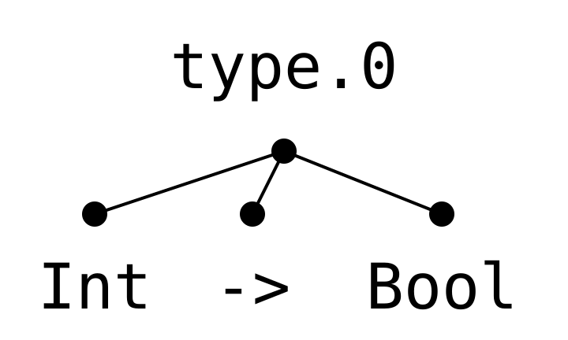

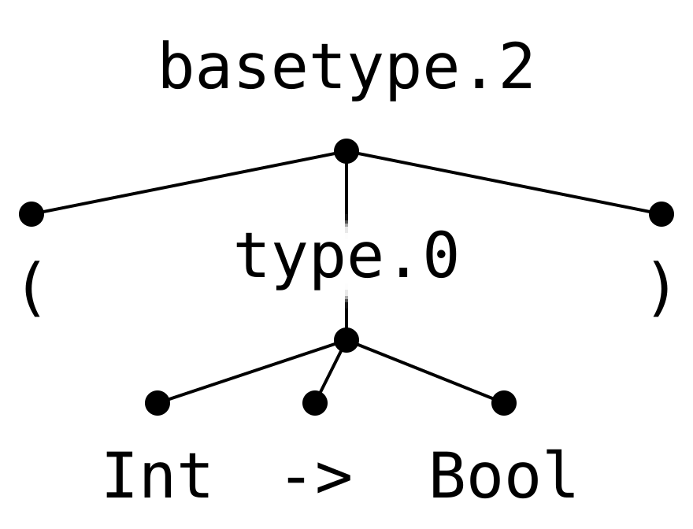

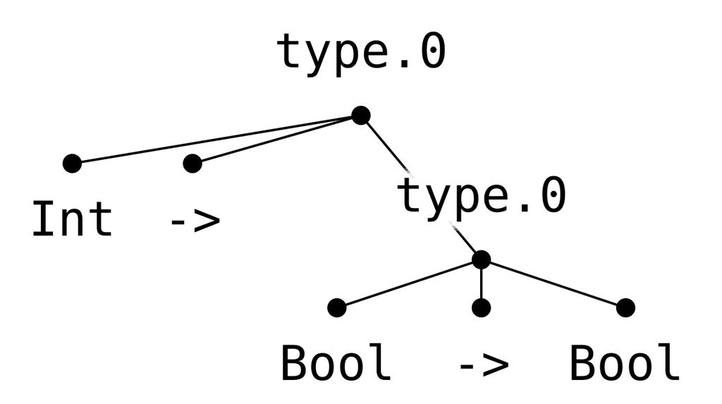

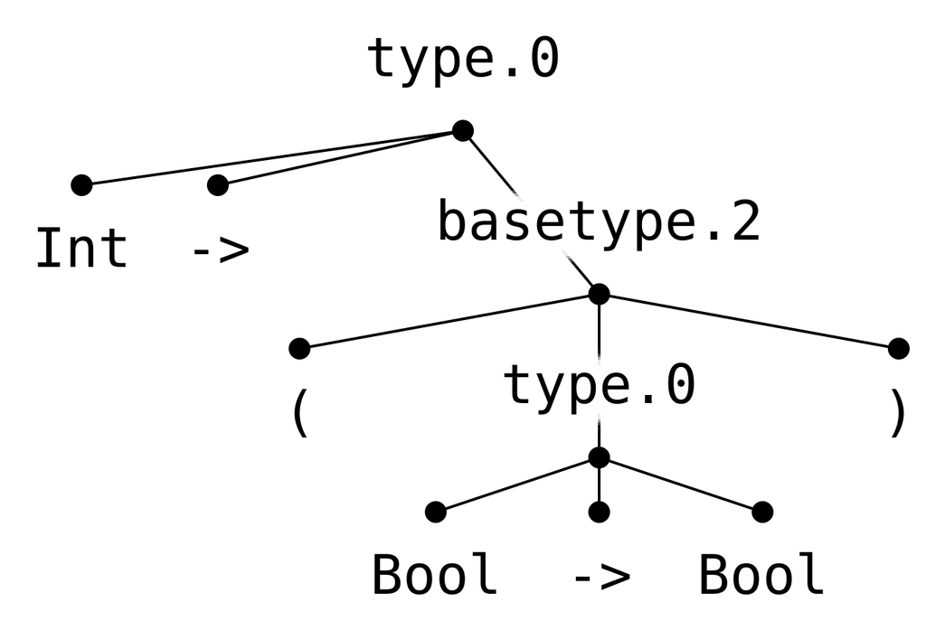

### Lambda expressions

Now we have what we need to define lambda expressions. As they act as a term, we add it there:

Backslash is the escape character, so use two of them to represent a single backslash.

We can also apply arguments to a lambda expression. We expand `expr`:

### What about nonsensical input?

With the current syntax, expresions as `If 5 Then True else False`, `True + 5`, `True 5` or `(\x : Int : x + 1) True` can be written. We allow these forms to be parsed, as the next stage of the compiler (the typechecker) will catch these errors. How to construct this, will be explained in a following section.

### Recap

We run this with

- `ALGT STFL.language examples.stfl expr -l` to show the parsetrees
- `ALGT STFL.language examples.stfl expr -l --ptsvg SVGnames` to render the parsetrees as SVG
- `ALGT STFL.language --lsvg SVGname.svg` to visualize the subtyping relationship.

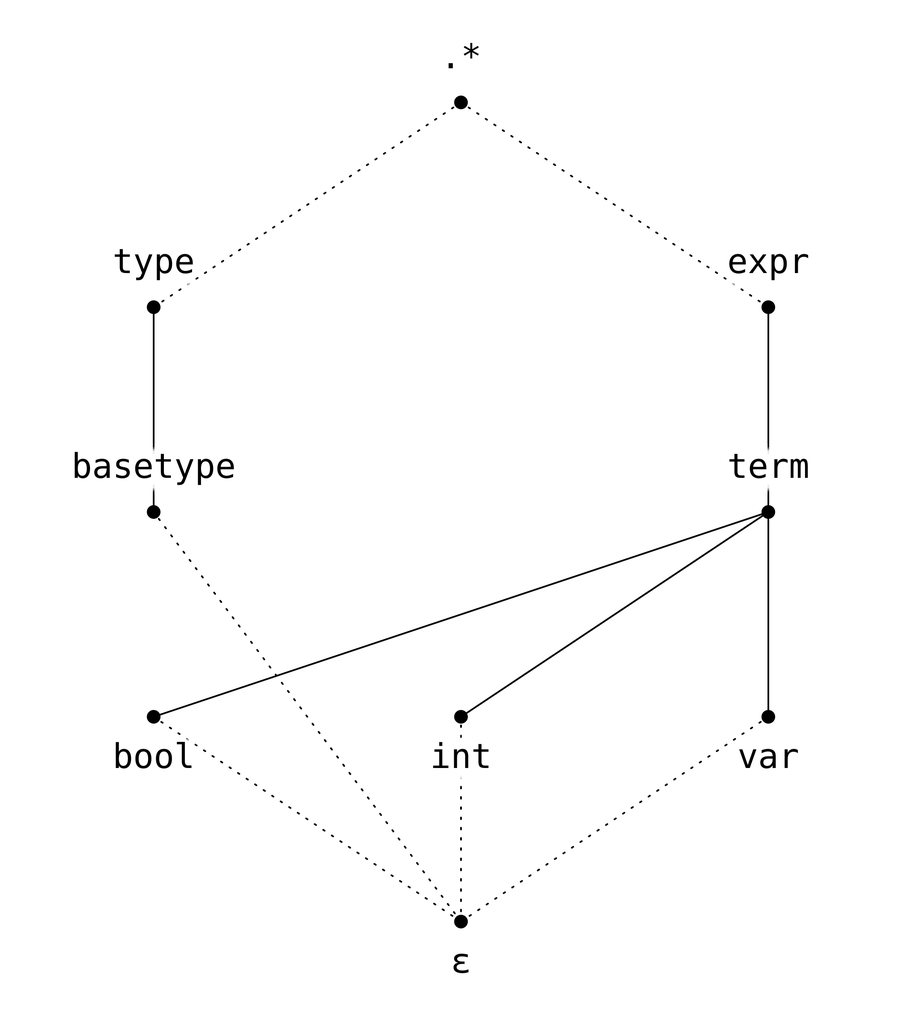

The final subtyping relationship of STFL.language

## Functions

### Substitution

To work with lambda expressions, we have to replace a variable in an expression by some other expression.

For example, we might want to replace `x` by `42`:

| Input expression | Output expression |
| --- | --- |
| `x` | `42` |
| `x + 1` | `42 + 1` |
| `If True Then x Else 0` | `If true Then 42 Else 0` |
| `(\\b : Bool . If b Then x Else y)` | `(\\b : Bool . If b Then 42 Else y)` |

Let's define this function!

### The function section

We add a new header to *STFL.language*:

In this function section, we give an attempt to define *subs*:

#### Function declaration

The `subs` is the name of the function. The `var -> expr -> expr -> expr` indicates the type of this function: it takes three arguments (namely a `var`, an `expr` and another `expr`) and gives calculates an `expr` with this. The syntactic form after the last arrow is always what is returned. [^8]

#### Pattern matching

Now, take a closer look to the second line of this function:

This thing is called a *clause*. When `subs("someVar", 42, "True")` is called, the parsetree `"someVar"` is named `x`, `42` is named `e` and `"True"` is matched against `"True"`. As these are the same, the patterns match and the right-hand side of the clause (that is right of the `=`) is returned; in this case `"True"`.

What happens if this clause doesn't match, e.g. for `subs("someVar", 42, "False")`? In that case, we check if the next pattern does match.

### Domain and codomain

It'll come in handy later on to be able to calculate the *domain* and *codomain* of a function type. The *domain* of a function is the type it can handle as input. The *codomain* of a function is the type it gives as output.

Examples of domain and codomain

[output not shown]

Now, let's define these functions!

### The function section

We add a new header to *STFL.language*:

In this function section, we can define the function *dom* in the following way:

So, what is going on here? Let's first take a look to the first line:

The `domain` is the name of the function. The `type -> type` indicates what syntactic form is taken as input (a `type`) before the `->` and what is given as output (again a `type`). [^9]

[figure not shown]

Relevant XKCD (by Randall Munroe, #917)

### Pattern matching

Let's have look at the body of the function:

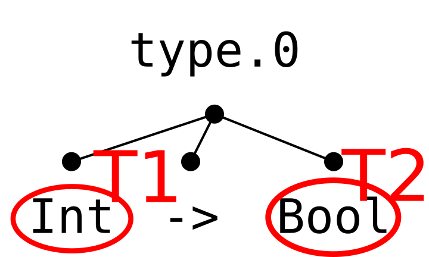

Pattern matching in action

## Relations and Rules

## Building smallstep

## Building bigstep

## Building a typechecker

## Properties

## Recap: used command line arguments

# Reference manual

## General

A language is defined in a `.language`-file. It starts (optionally) with a title:

Comments start with a `#` and can appear quasi everywhere.

Syntax, functions, relations, ... are all defined in their own sections:

A section header starts with an upper case, is underlined with `=` and followed by a blank line.

## Syntax

All syntax is defined in the `Syntax` section. It consists out of `BNF`-rules, of the form

Choices might be written on multiple lines, as long as at least one tab precedes them:

### Literals

A string that should be matched exactly, is enclosed in `"` (double quotes). Some characters can be escaped with a backslash, namely:

Escape sequences

| Sequence | Result |
| --- | --- |
| `\n` | newline |
| `\t` | tab |
| `\"` | double quote |
| `\\` | backslash |

### Parsing order

Rules are parsed **left to right**, in other words, choices are tried in order. No backtracking happens when a choice is made; the parser is a *recursive descent parser*. This has two drawbacks: left recursion results in an infinite loop and the ordering of choices does matter.

### Builtin syntactic forms

Some syntactic forms are already provided for your convenience, namely:

Builtin syntax

| Builtin | Meaning | Regex |
| --- | --- | --- |
| `Identifier` | Matches an identifier | `[a-z][a-zA-Z0-9]*` |
| `Number` | Matches an (negative) integer. Integers parsed by this might be passed into the builtin arithmetic functions. | `-?[0-9]*` |
| `Lower` | Matches a lowercase letter | `[a-z]` |
| `Upper` | Matches an uppercase letter | `[A-Z]` |
| `Digit` | Matches an digit | `[0-9]` |
| `String` | Matches a double quote delimted string | `"([^"\]\|\"\|\\)*"` |

### Subtyping relationship

A syntactic form equals a (possibly infinite) set of strings. By using a syntactic form `a` as choice in other syntactic form `b`, `a` will be a subset of be, giving the natural result that `a` is a subtype of `b`.

In the following examle, `bool` and `int` are both subsets of `expr`. This can be visualised with the `--lsvg Output.svg`-flag.

```
bool    ::= "True" | "False"
int     ::= Number
expr    ::= ... | bool | int
```

### Whitespace in sequences

Whitespace (the characters `" "`,`"\t"`), is parsed by default (and ignored completely). If you want to parse a whitespace sensitive language, use other symbols to declare the rule:

Whitespace modes

| Operator | Meaning |
| --- | --- |
| `::=` | Totally ignore whitespace |
| `~~=` | Parse whitespace for this rule only |
| `//=` | Parse whitespace for this rule and all recursively called rules |

This gives rise to the following behaviour:

Whitespace mode examples

| Syntax | Matching String |
| --- | --- |
| `a ::= "b" "c" x` | `b c x y` |
| `x ::= "x" "y"` | `bcxy` |
|  | `b\tc\tx\ty` |
|  | `b c\txy` |
|  | ... |
| `a ~~= "b" "c" x` | `bcx y` |
| `x ::= "x" "y"` | `bcxy` |
|  | `bcx\ty` |
| `a //= "b" "c" x` | `bcxy` |
| `x ::= "x" "y"` |  |

## Functions

### Patterns and expressions

| Expr | Name | As expression |
| --- | --- | --- |
| `x` | Variable | Recalls the parsetree associated with this variable |
| `42` | Number | This number |
| `"Token"` | Literal | This string |
| `func(arg0, arg1, ...)` | Function call | Evaluate this function |
| `!func:type(arg0, ...)` | Builtin function call | Evaluate this builtin function, let it return a `type` |
| `(expr or pattern:type)` | Ascription | Checks that an expression is of a type. Bit useless |
| `e[expr or pattern]` | Evaluation context | Replugs `expr` at the same place in `e`. Only works if `e` was created with an evaluation context |
| `a "b" (nested)` | Sequence | Builds the parse tree |

| Expr | As pattern |
| --- | --- |
| `x` | Captures the argument as the name. If multiple are used in the same pattern, the captured arguments should be the same or the match fails. |
| `42` | Argument should be exactly this number |
| `"Token"` | Argument should be exactly this string |
| `func(arg0, arg1, ...)` | Evaluates the function, matches if the argument equals the result. Can only use variables which are declared left of this pattern |
| `!func:type(arg0, ...)` | Evaluates the builtin function, matches if the argument equals the result. Can only use variables which are declared left of this pattern |
| `(expr or pattern:type)` | Check that the argument is an element of `type` |
| `e[expr or pattern]` | Matches the parsetree with `e`, searches a subpart in it matching `pattern` |
| `a "b" (nested)` | Splits the parse tree in the appropriate parts, pattern matches the subparts |

### Typechecking

#### Equality

When equality checks are used in the pattern matching, the variable will be typed as the smallest common supertype of both types. If such a supertype does not exist, an error message is given.

Note that using a supertype might be a little *too* loose, but won't normally happen in real-world examples.

### Totality- and liveabilitychecks

### Higher order functions and currying?

Are not possible for now (v 0.1.15). Perhaps in a future version or when someone really needs it and begs for it.

### Builtin functions

| name | Descr | Arguments |
| --- | --- | --- |
| `plus` | Gives a sum of all arguments (0 if none given) | Ints only |
| `min` | Gives the first argument, minus all the other arguments | At least 1, Ints only |
| `mul` | Multiplies all the arguments. (1 if none given) | Ints only |
| `div` | Gives the first argument, divided by the product of the other arguments. (Integer division, rounded down)) | At least 1, Ints only |
| `mod` | Gives the first argument, module the product of the other arguments. | At least 1, Ints only |
| `neg` | Gives the negation of the argument | Exactly 1, Ints only |
| `equal` | Checks that all the arguments are equal. Gives 1 if so, 0 if not. | At least 2 |
| `error` | Stops the function, gives a stack trace. When used in a rule, this won't match a predicate |  |
| `freshvar` | Generates an identifier not present in the arguments. If the first argument is an identifier, identifiers are based on that form. |  |
| `subs` | (expression to replace, to replace with, in this expression) Replaces each occurence of the first expression by the second, in the third argument | Exactly 3 |

## Relations and Rules

## Properties

## Command line flags

# Used concepts and algorithms

# Dynamization and gradualization

Thanks to

Ilion Beyst, for always being up to date, giving ideas, spotting bugs at first sight, implementing `Nederlands` and his enthousiasm in general Isaura Claeys, for proofreading and finding a lot of typos

[^1]: Note the similarity of *ALGT* and *AGT* . The tool started its life as *AGT*, based on the paper [*Abstracting Gradual Typing*](https://pleiad.cl/papers/2016/garciaAl-popl2016.pdf). When it became more general, another name and acronym was chosen.
[^2]: Actually, the extension doesn't matter at all.
[^3]: Backus-Naur-form, as introduced by John Backus in the [ALGOL60-report](http://www.softwarepreservation.org/projects/ALGOL/report/Algol60_report_CACM_1960_June.pdf).
[^4]: Don't worry about spaces and tabs, we deal with them. If you want need to parse stuff like "duizendeneen" or whitespace sensitive languages, please refer to the reference manual
[^5]: These images can be created with `ALGT STLF.language examples.stfl -l --ptsvg Outputname`
[^6]: These images can be created with `ALGT STLF.language examples.stfl -l --ptsvg Outputname`
[^7]: Creating this svg might take a long time for complicated syntaxes, as ALGT calculates the ordering of labels resulting in the least intersecting lines.
[^8]: You probably noticed the similarity between the types declared in our own STFL and this declaration. This is intentional.
[^9]: You probably noticed the similarity between the types declared in our own STFL and this declaration. This is intentional.